# Titanic Facts

### Homoscedasticitat dels residus

- Les gràfiques “Residuales vs Fitted” donen informació de l’homoscedasticitat:

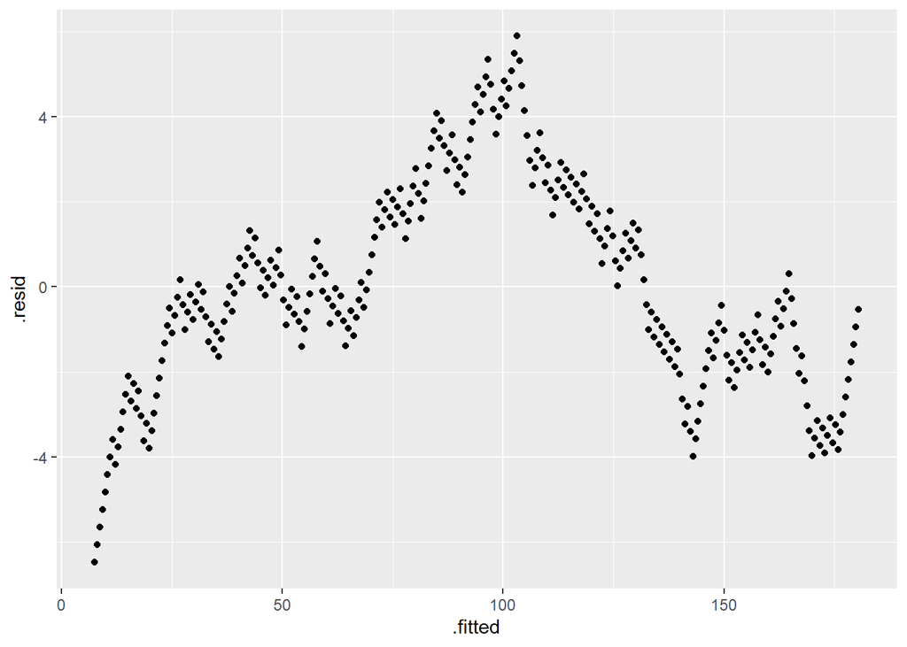

```r
ggplot(alles, aes(x=.fitted, y=.resid)) +
  geom_point()
```

També amb plot(alles):

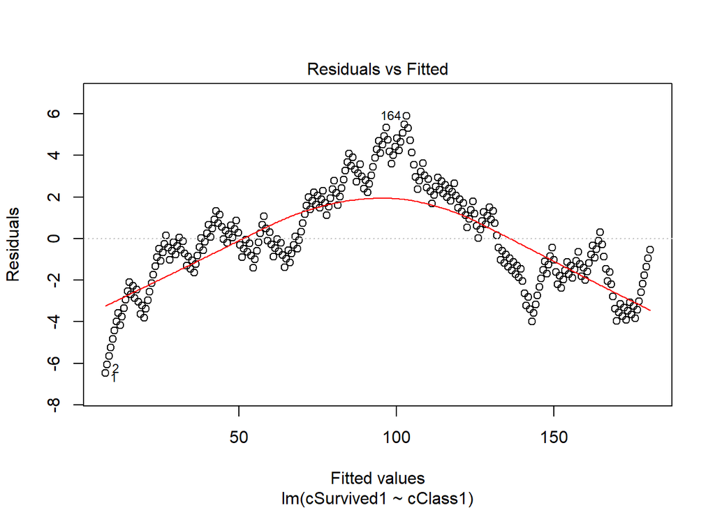

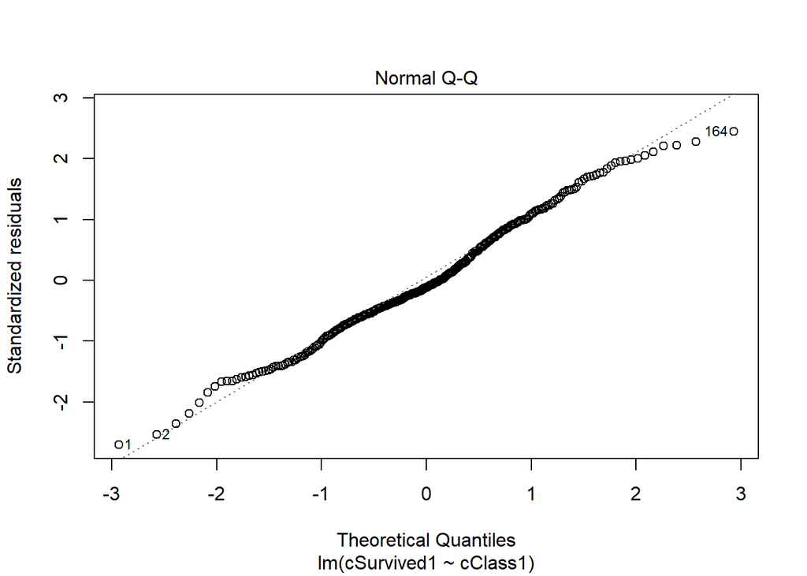

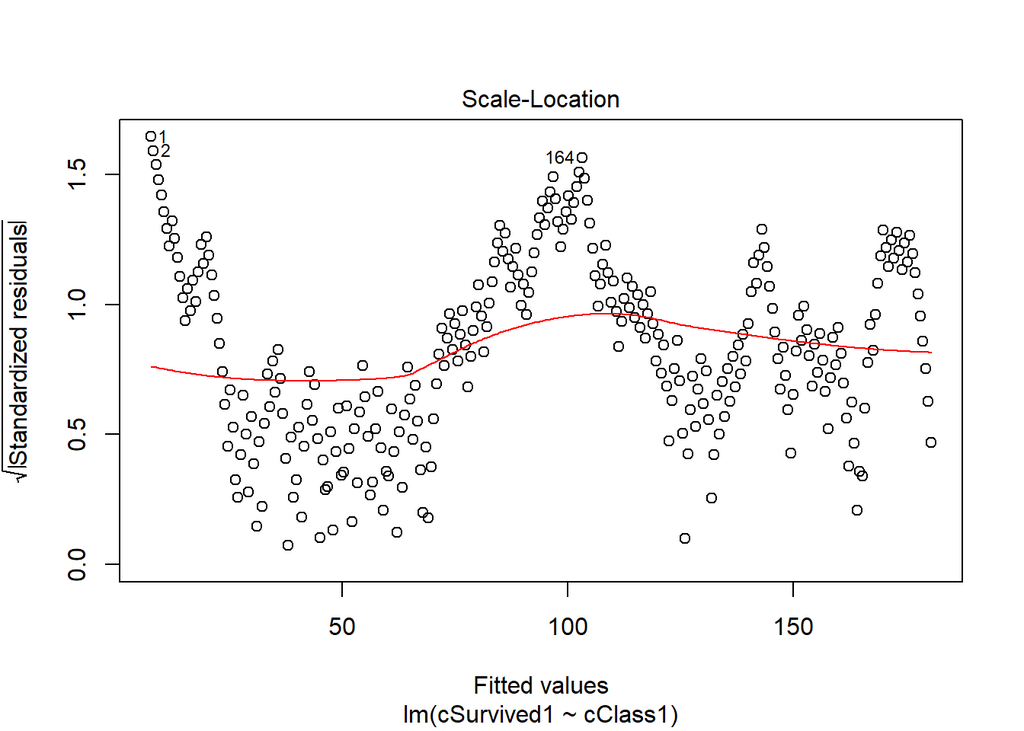

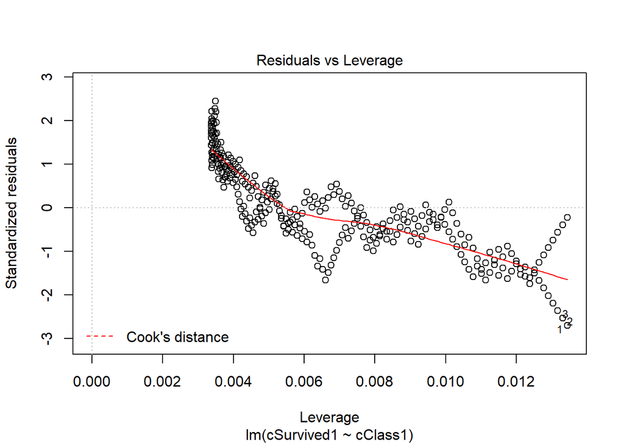

```r
plot(alles)
```

### Es dedueix la no homoscedasticitat dels residus en diversos trams

### ANOVA no paramètric: test de Kruskal-Wallis

```r
fAgeSample=sample(allTf$Age, length(allTm$Age))
kruskal.test(fAgeSample,allTm$Age)
```

```
##
##  Kruskal-Wallis rank sum test
##
## data:  fAgeSample and allTm$Age
## Kruskal-Wallis chi-squared = 60.795, df = 57, p-value = 0.3409
```

### Estadístics amb la edat ~ Group i Sex (Age única variable numèrica)

- Comprovem l’edat mitjana per classes:

```r
allTM=allT%>%
  group_by(Class,Sex)%>%
  summarize(edat_mitjana=mean(Age))
allTM
```

```
## # A tibble: 8 x 3
## # Groups:   Class [4]
##   Class Sex   edat_mitjana
##   <dbl> <chr>        <dbl>
## 1     0 f             36.0
## 2     0 m             30.7
## 3     1 f             37.0
## 4     1 m             40.8
## 5     2 f             28.1
## 6     2 m             29.9
## 7     3 f             22.9
## 8     3 m             25.8
```

.

### El resultat amb estadístics diu que la relació és feble:

- amb la función aov():

```r
loci3=aov(Age~Group*Sex,data=allT) # considerem interacció
print(loci3)
```

```
## Call:
##    aov(formula = Age ~ Group * Sex, data = allT)
##
## Terms:
##                     Group       Sex Group:Sex Residuals
## Sum of Squares   49272.05   1598.73   2779.76 250384.41
## Deg. of Freedom        13         1         7      2155
##
## Residual standard error: 10.77904
## 6 out of 28 effects not estimable
## Estimated effects may be unbalanced
```

- amb lm():

```r
loci3lm=lm(Age~Group*Sex,data=allT)
summary(loci3lm)
```

```
##
## Call:
## lm(formula = Age ~ Group * Sex, data = allT)
##
## Residuals:
##     Min      1Q  Median      3Q     Max
## -37.774  -6.254  -0.847   5.973  48.153
##
## Coefficients: (6 not defined because of singularities)
##                        Estimate Std. Error t value Pr(>|t|)
## (Intercept)            36.46316    1.10591  32.971  < 2e-16 ***
## Group1c1serv            6.03684    2.77090   2.179 0.029465 *
## Group1c2serv            0.03684    7.70174   0.005 0.996184
## Group1classServ        -2.05575    2.35080  -0.874 0.381950
## Group2class            -8.25483    1.54431  -5.345 9.98e-08 ***
## Group3class           -13.59040    1.33783 -10.159  < 2e-16 ***
## GroupDeck              -8.51996    1.64890  -5.167 2.60e-07 ***
## GroupEngineering      -11.12216    1.05538 -10.539  < 2e-16 ***
## Groupgarantee         -12.66308    3.69585  -3.426 0.000623 ***
## Groupofficer           -5.14919    3.90808  -1.318 0.187785
## GroupOrchestra        -14.89919    3.90808  -3.812 0.000141 ***
## GroupPostman           -2.17419    4.89767  -0.444 0.657142
## Grouprestaurant       -12.96316    7.70174  -1.683 0.092492 .
## GroupVictualling        0.73684    2.65187   0.278 0.781148
## Sexm                    5.31104    1.40450   3.781 0.000160 ***
## Group1c1serv:Sexm     -13.11944    4.47731  -2.930 0.003423 **
## Group1c2serv:Sexm      -1.56104    9.43999  -0.165 0.868673
## Group1classServ:Sexm   -7.07559    3.81772  -1.853 0.063968 .
## Group2class:Sexm       -3.29699    1.94608  -1.694 0.090378 .
## Group3class:Sexm       -2.33671    1.66445  -1.404 0.160493
## GroupDeck:Sexm               NA         NA      NA       NA
## GroupEngineering:Sexm        NA         NA      NA       NA
## Groupgarantee:Sexm           NA         NA      NA       NA
## Groupofficer:Sexm            NA         NA      NA       NA
## GroupOrchestra:Sexm          NA         NA      NA       NA
## GroupPostman:Sexm            NA         NA      NA       NA
## Grouprestaurant:Sexm   -3.46775    7.86134  -0.441 0.659174
## GroupVictualling:Sexm -11.48394    2.84550  -4.036 5.63e-05 ***
## ---
## Signif. codes:  0 '***' 0.001 '**' 0.01 '*' 0.05 '.' 0.1 ' ' 1
##
## Residual standard error: 10.78 on 2155 degrees of freedom
## Multiple R-squared:  0.1765, Adjusted R-squared:  0.1684
## F-statistic: 21.99 on 21 and 2155 DF,  p-value: < 2.2e-16
```

- Els NA: en la tripulacio de deck, engineering, garantee, officer orchestra i postman no hi ha dones

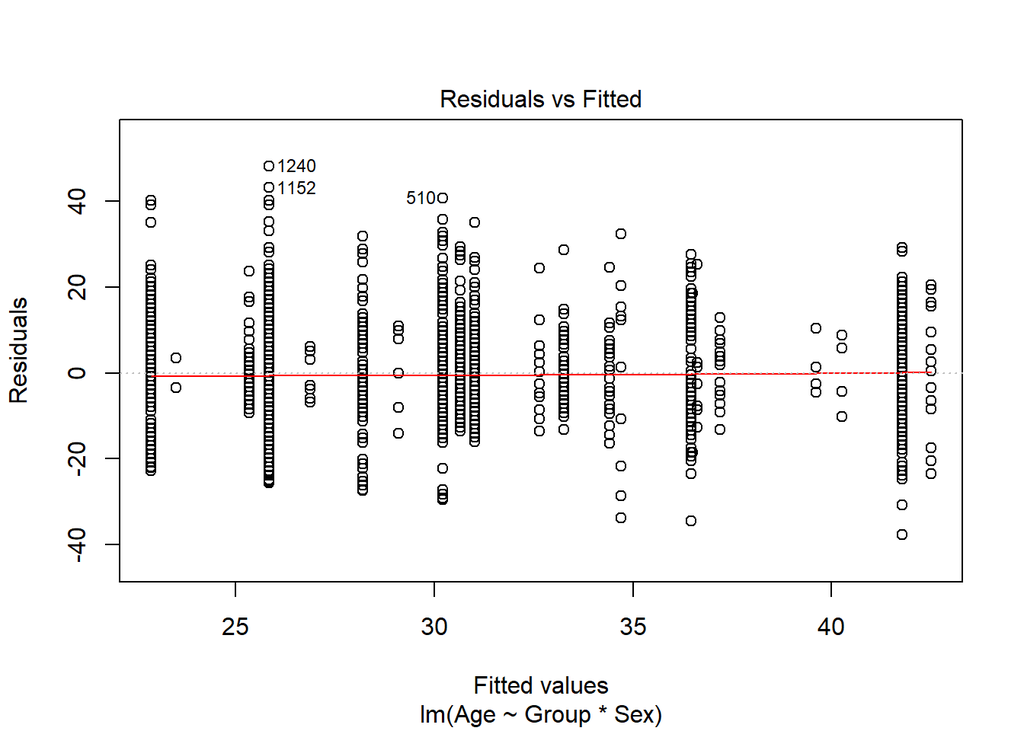

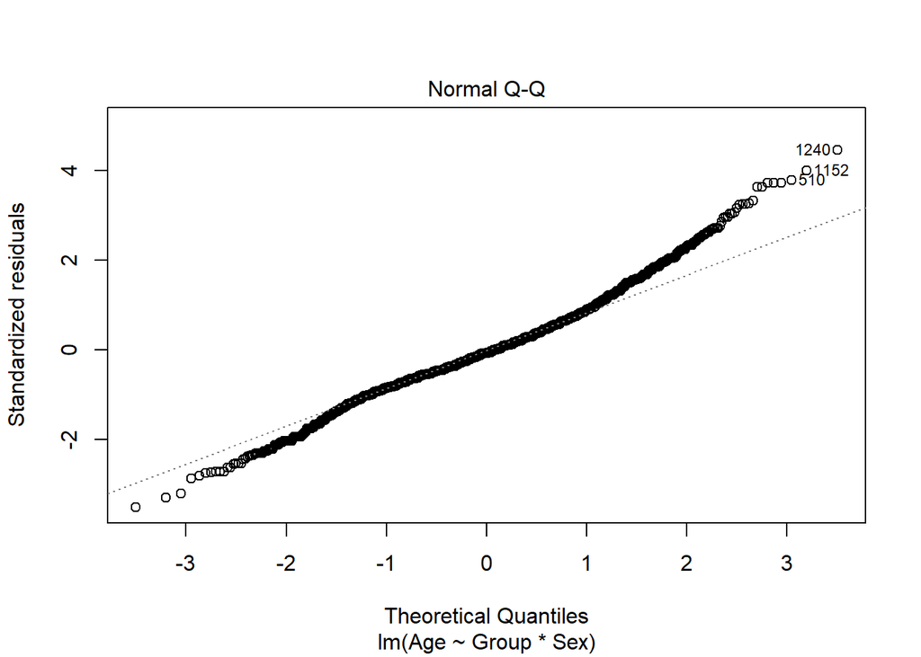

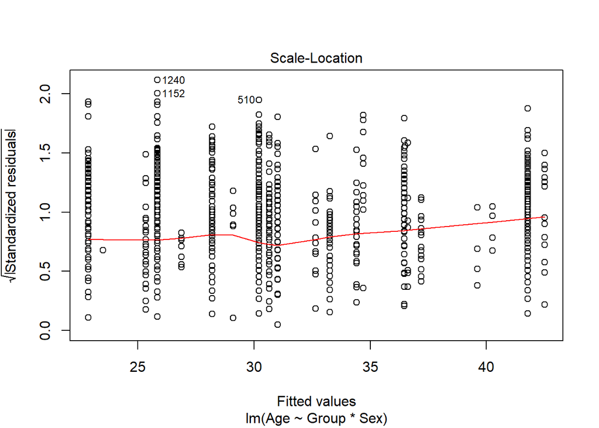

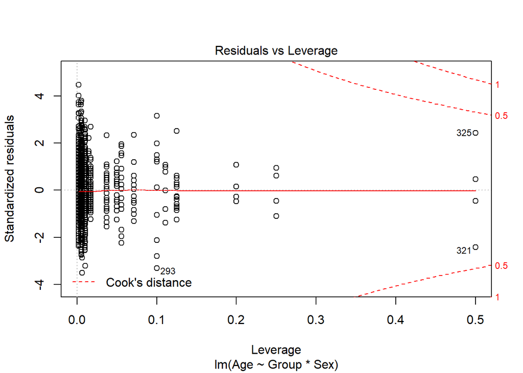

```r
plot(loci3lm)
```

# 5. Gràfiques i taules

## 5.1 Gràfiques

### 5.1.1 Seleccionem columnes per l’anàlisi

```r
selT = allT %>%
  select(Age,Boarded,Lifeboat,Sex,Class,Group,Survived)
head(selT,3)
```

```
## # A tibble: 3 x 7
##     Age Boarded Lifeboat Sex   Class Group      Survived
##   <dbl> <chr>   <chr>    <chr> <dbl> <chr>      <lgl>
## 1    19 S       <NA>     m         2 1classServ FALSE
## 2    18 S       11       f         2 1classServ TRUE
## 3    33 S       8        f         1 1classServ TRUE
```

### 5.1.2 Gràfiques de les variables: la numèrica Age

- Distribució de l’edat, per classes

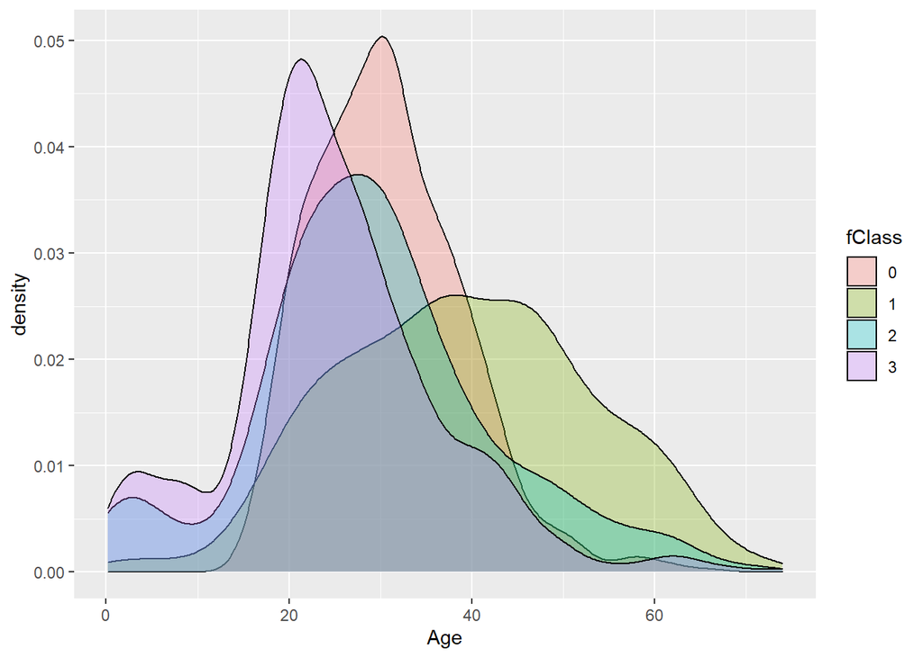

```r
fClass = as.factor(allT$Class)
ggplot(allT,aes(x = Age, fill = fClass)) +
  geom_density(alpha=0.3)
```

-Distribució de l’edat, per sexe

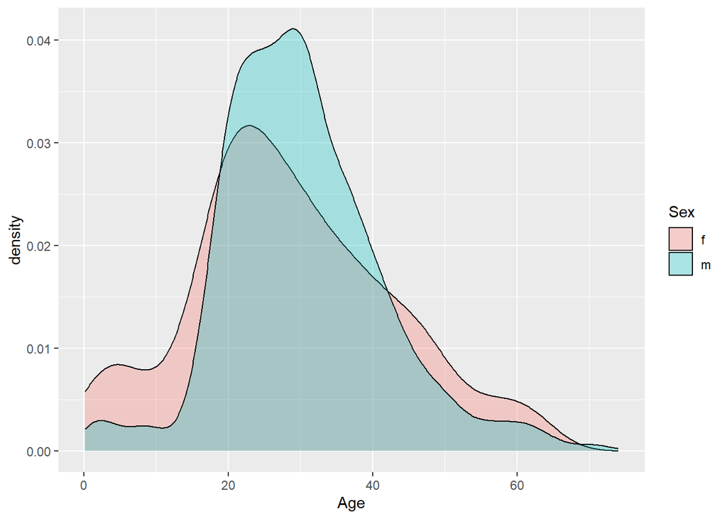

```r
ggplot(allT,aes(x = Age, fill = Sex)) +
  geom_density(alpha=0.3)
```

Age, Group i Sex

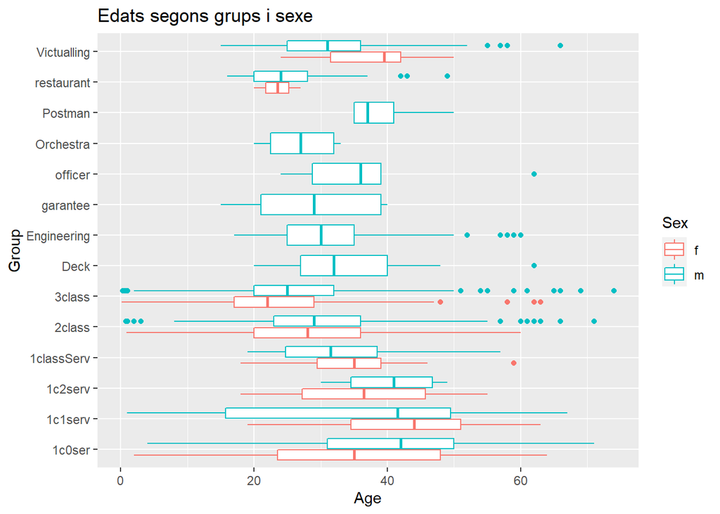

```r
ggplot(selT, aes(x=Age,y=Group,col=Sex)) +
  geom_boxplot() +
  labs(title = 'Edats segons grups i sexe')
```

```r
# edat en funció del grup:

# 1c0ser passatger de primera classe sense servent
# 1c1ser passatger de primera classe amb 1 servent també en 1a
# 1c2ser passatger de primera classe amb 2 servents també en 1a
# 1classServ servent en 1a classe (secretary, valet, nurse,..)
# 2class passatger de segona classe
# 3class passatger de tercera classe
# resta: tripulació (deck, marineria, engineering, tripulació a càrrec de les màquines,..
```

‘Facts’:Entre els tripulants, hi ha outliers que corresponen a personal experimentat, com el capità en officer, o els enginyers d’Enginnering; entre els passatgers, en 2a classe i 3a classe, pels xiquets i hi ha gent molt més major que la mitjana.

Age, Lifeboat i Sex

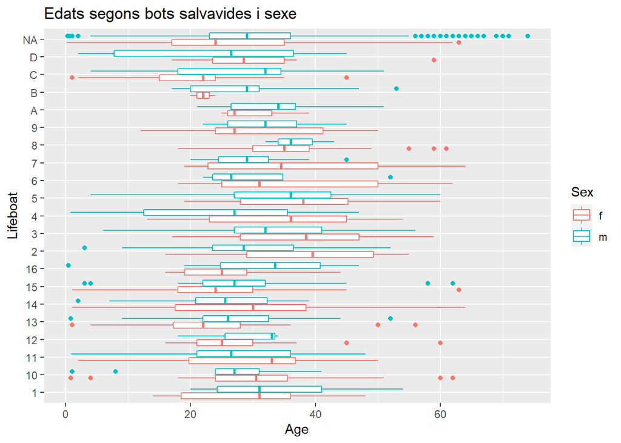

```r
ggplot(selT, aes(x=Age,y=Lifeboat,col=Sex)) +
  geom_boxplot()+
  labs(title = 'Edats segons bots salvavides i sexe')
```

Class, Age i Group

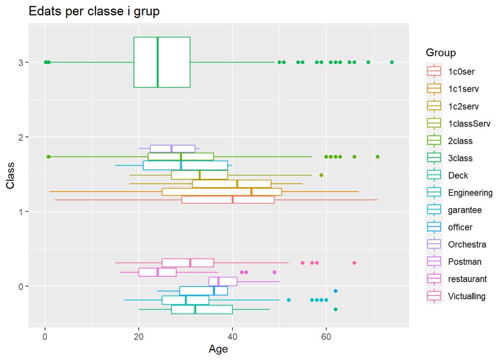

```r
ggplot(allT,aes(y=Class,x=Age,color=Group)) +
  geom_boxplot() +
  labs(title = 'Edats per classe i grup')
```

El gran nombre de outliers en el apartat sense nom són ofegats (‘no boat’)

### 5.1.3 Gràfiques de les variables tipus factor

Salvats, Lifeboat i Sex

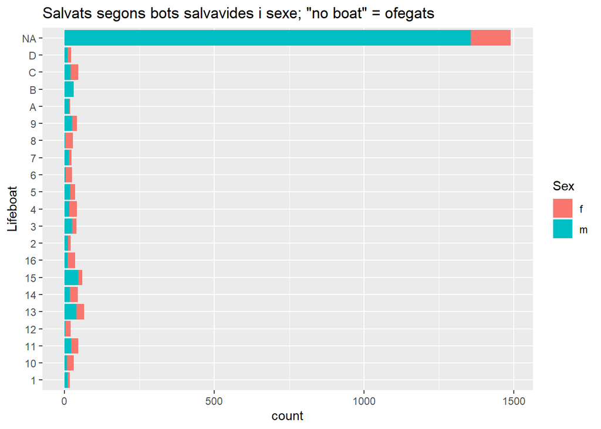

```r
ggplot(data=selT, aes(y=Lifeboat, fill=Sex)) +
  geom_bar() +
  labs(title = 'Salvats segons bots salvavides i sexe; "no boat" = ofegats')
```

El tòpic de què es van salvar moltes dones en els bots per triatge no és evident: hi ha molta proporció d’homes als bots, i moltes dones ofegades.

Salvats segons grups:

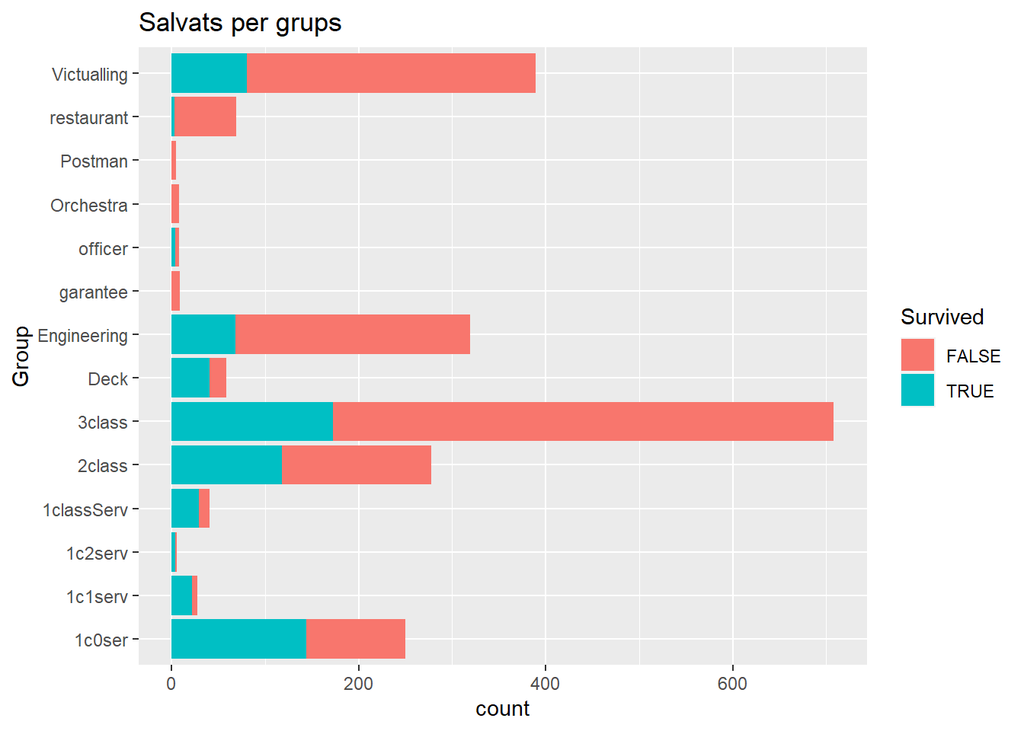

```r
ggplot(selT, aes(fill=Survived, y=Group)) +
  geom_bar()+
  labs(title = 'Salvats per grups')
```

La 3a i 2a classe, entre els passatgers, i tots els tripulants llevat de marineria i oficials són la majoria d’ofegats

Salvats segons sexe:

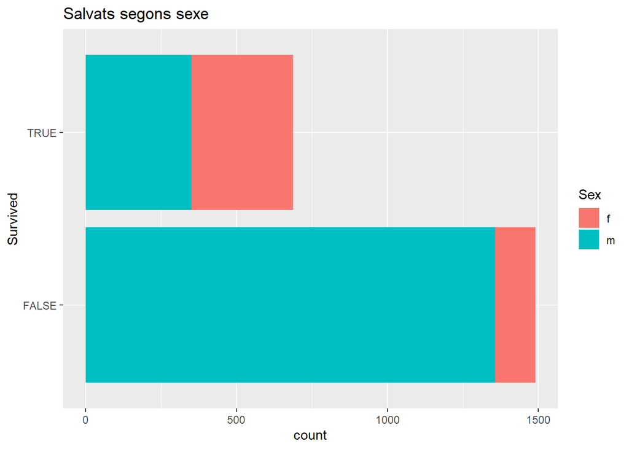

```r
ggplot(selT, aes(y=Survived, fill=Sex)) +
  geom_bar()+
  labs(title = 'Salvats segons sexe')
```

Nens salvats segons sexe:

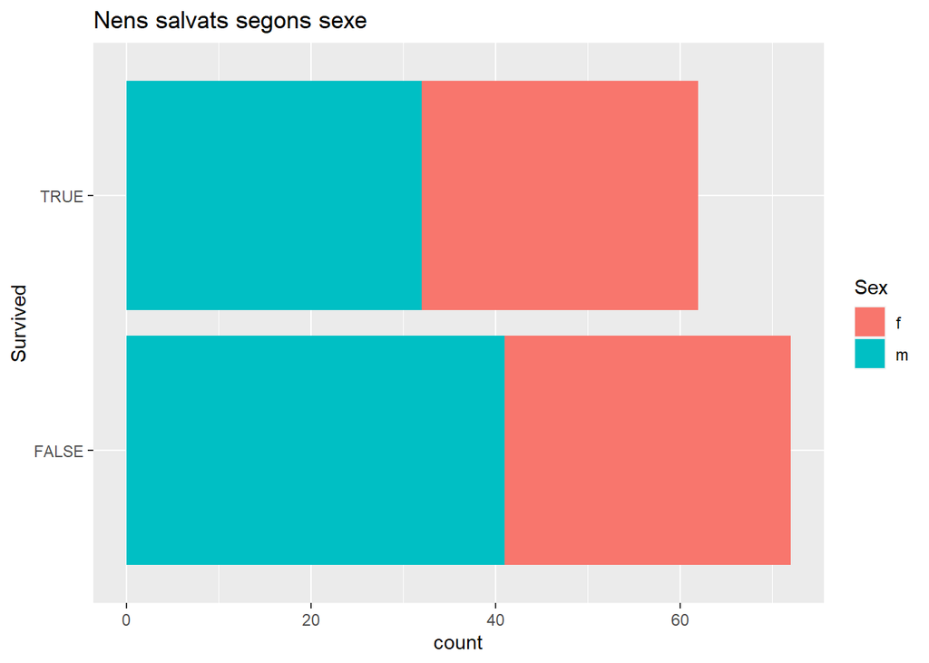

```r
nens=selT %>%
  filter(Age<=15)
ggplot(nens, aes(y=Survived, fill=Sex)) +
  geom_bar()+
  labs(title = 'Nens salvats segons sexe')
```

Un altre tòpic de triatge de nens gens clar: hi ha més nens morts que salvats. No va ser per igual en cada classe, quasi tots els nens ofegats van ser de la 3a classe, com podem veure en el següent gràfic:

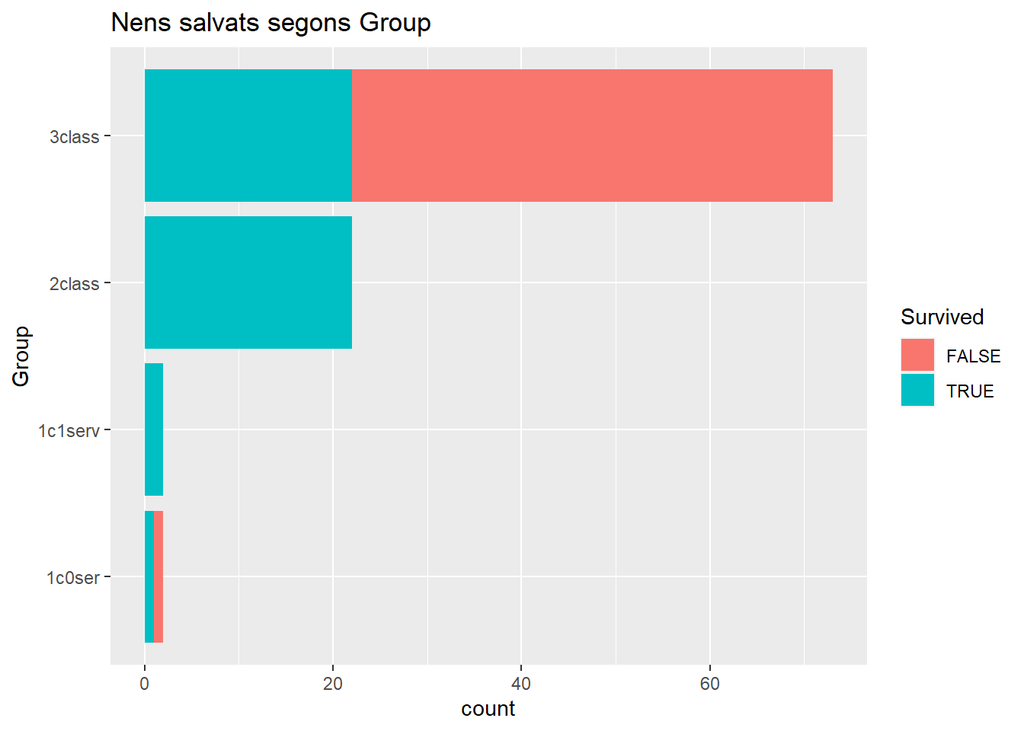

```r
nens=allT %>%
  filter(Age<=10)
ggplot(nens, aes(fill=Survived, y=Group)) +
  geom_bar() +
  labs(title = 'Nens salvats segons Group')
```

Comprovem els salvats segons classe:

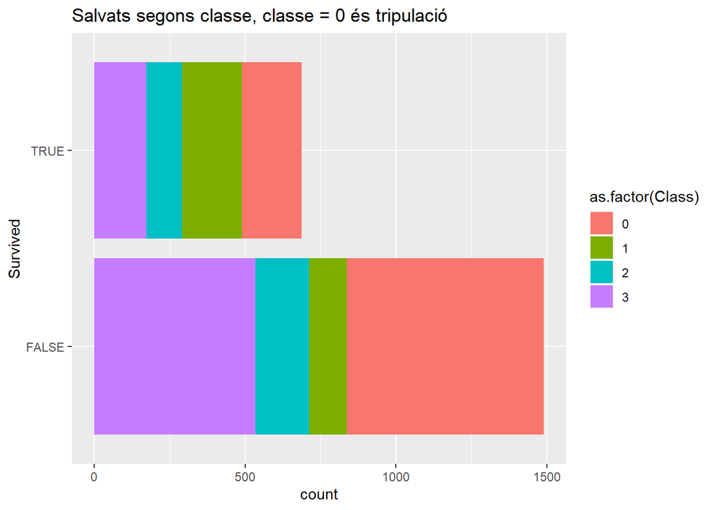

```r
ggplot(selT, aes(y=Survived, fill=as.factor(Class))) +
  geom_bar()+
  labs(title = 'Salvats segons classe, classe = 0 és tripulació')
```

La tripulació i els passatgers de 3a classe van ser els més afectats.

### 5.1.4 Regressió lineal sexe vs. salvats

Una teoria estesa diu que les dones del Titanic es van salvar en una proporció molt superior als homes. També és cert que hi havia moltes menys dones que homes al Titanic.

Individualment, cada salvat o ofegat es pot representar per un factor 0 o 1. Si sumem casos, obtenim una variable creixent numèrica.El mateix podem dir de Sex: en el fitxer representa per 0 una dona, per 1 un home, que sumats, ens donen el nombre de homes. El pendent es, per tant, la tasa de salvats dels homes

Per veure com varia l’acumulat de les dos variables, i com el pendent ens dona la probabilitat mitjana de que es salve un home en el Titanic. primer creem estes variables: cSurvived i cSex:

```r
selTn = selT %>%
  select(Sex, Class, Survived) %>%
  mutate_if(is.character, as.factor) %>%
  mutate_if(is.factor,as.numeric) %>%
  mutate_if(is.logical,as.numeric) %>%
  mutate(SexN = Sex - 1) %>%
  mutate(cSex  = cumsum(SexN), cSurvived = cumsum(Survived))
head(selTn, 3)
```

```
## # A tibble: 3 x 6
##     Sex Class Survived  SexN  cSex cSurvived
##   <dbl> <dbl>    <dbl> <dbl> <dbl>     <dbl>
## 1     2     2        0     1     1         0
## 2     1     2        1     0     1         1
## 3     1     1        1     0     1         2
```

Representarem gràficament cSurvived vs. cSex:

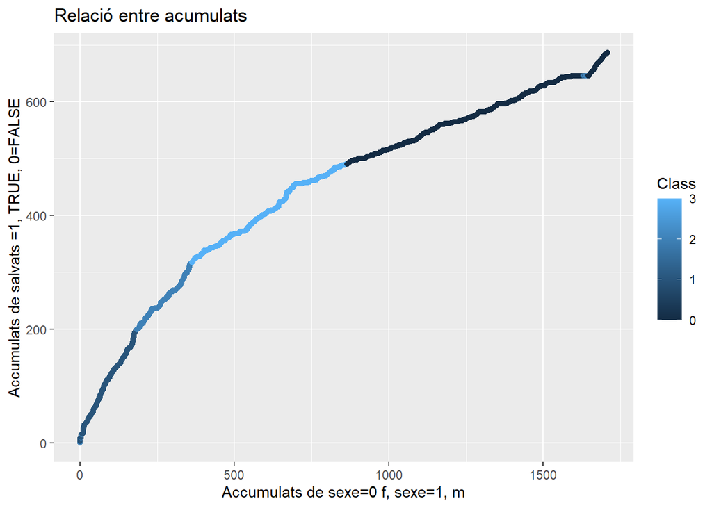

```r
ggplot(selTn, aes(x = cSex, y=cSurvived, color=Class)) +
  geom_point() +
  labs(x='Accumulats de sexe=0 f, sexe=1, m',y='Accumulats de salvats =1, TRUE, 0=FALSE' , title = 'Relació entre acumulats')
```

Ajustem una regressió lineal amb lm() a partir de la meitat, a fi de fer una mostra més representativa:

```r
selTn750 = selTn %>%
  filter(cSex > 750)
surv.fit = lm(cSurvived ~ cSex, data = selTn750)
summary(surv.fit)
```

```
##
## Call:
## lm(formula = cSurvived ~ cSex, data = selTn750)
##
## Residuals:
##      Min       1Q   Median       3Q      Max
## -12.1612  -2.0608  -0.2084   2.1699  16.0588
##
## Coefficients:
##              Estimate Std. Error t value Pr(>|t|)
## (Intercept) 3.010e+02  4.980e-01   604.4   <2e-16 ***
## cSex        2.166e-01  3.974e-04   545.0   <2e-16 ***
## ---
## Signif. codes:  0 '***' 0.001 '**' 0.01 '*' 0.05 '.' 0.1 ' ' 1
##
## Residual standard error: 3.559 on 1009 degrees of freedom
## Multiple R-squared:  0.9966, Adjusted R-squared:  0.9966
## F-statistic: 2.97e+05 on 1 and 1009 DF,  p-value: < 2.2e-16
```

### El pendent 0,217 que s’obté és aproximadament la fracció del total d’homes que se salva. Adjusted R-squared: 0.9966

De la taula de contingència, el valor és 20,6%:

```r
100*prop.table( table(allT$Sex, allT$Survived), margin=1)
```

```
##
##        FALSE     TRUE
##   f 28.35821 71.64179
##   m 79.44965 20.55035
```

## 5.2 Taules

### Salvats en xifres

```r
100*prop.table( table(allT$Sex, allT$Survived), margin=1)
```

```
##
##        FALSE     TRUE
##   f 28.35821 71.64179
##   m 79.44965 20.55035
```

### Salvats per grups

-Salvats, en %, segons els grups:

```r
# % de salvats (Survived=True) en funció del grup:

# 1c0ser passatger de primera classe sense servent
# 1c1ser passatger de primera classe amb 1 servent també en 1a
# 1c2ser passatger de primera classe amb 2 servents també en 1a
# 1classServ servent en 1a classe (secretary, valet, nurse,..)
# 2class passatger de segona classe
# 3class passatger de tercera classe
# resta: tripulació (deck, marineria, engineering, tripulació a càrrec de les màquines,..

100*prop.table(table(allT$Group,allT$Survived),margin=1)
```

```
##
##                    FALSE       TRUE
##   1c0ser       42.400000  57.600000
##   1c1serv      21.428571  78.571429
##   1c2serv      33.333333  66.666667
##   1classServ   29.268293  70.731707
##   2class       57.553957  42.446043
##   3class       75.564972  24.435028
##   Deck         30.508475  69.491525
##   Engineering  78.683386  21.316614
##   garantee    100.000000   0.000000
##   officer      50.000000  50.000000
##   Orchestra   100.000000   0.000000
##   Postman     100.000000   0.000000
##   restaurant   95.652174   4.347826
##   Victualling  79.177378  20.822622
```

```r
table(allT$Group,allT$Survived)
```

```
##
##               FALSE TRUE
##   1c0ser        106  144
##   1c1serv         6   22
##   1c2serv         2    4
##   1classServ     12   29
##   2class        160  118
##   3class        535  173
##   Deck           18   41
##   Engineering   251   68
##   garantee        9    0
##   officer         4    4
##   Orchestra       8    0
##   Postman         5    0
##   restaurant     66    3
##   Victualling   308   81
```

- Salvats ordenats per càrrec

```r
allT %>%
  group_by(Position) %>%
  count(Survived) %>%
  rename(n_by_position=n)
```

```
## # A tibble: 247 x 3
## # Groups:   Position [213]
##    Position                Survived n_by_position
##    <chr>                   <lgl>            <int>
##  1 1classPass              FALSE              114
##  2 1classPass              TRUE               170
##  3 2classPass              FALSE              160
##  4 2classPass              TRUE               118
##  5 3classPass              FALSE              535
##  6 3classPass              TRUE               173
##  7 Able Seaman             FALSE                9
##  8 Able Seaman             TRUE                23
##  9 Assistant Baker         FALSE                2
## 10 Assistant Boots Steward FALSE                1
## # … with 237 more rows
```

```r
nens=allT %>%
  filter(Age<15) %>%
  group_by(Class)%>%
  count(Survived) %>%
  rename(n_nens=n)
nens
```

```
## # A tibble: 6 x 3
## # Groups:   Class [3]
##   Class Survived n_nens
##   <dbl> <lgl>     <int>
## 1     1 FALSE         1
## 2     1 TRUE          6
## 3     2 FALSE         1
## 4     2 TRUE         26
## 5     3 FALSE        63
## 6     3 TRUE         26
```

### Salvats: distribució als bots

- Ocupació dels bots:

```r
bots=allT %>%
  group_by(Lifeboat) %>%
  count(Survived) %>%
  rename(n_by_boat=n)
```

```r
bots$capacity=c(NA,rep(65,times=6),40,40,rep(65,times=8),rep(47,times=4))
bots$percentFull=100*bots$n_by_boat/bots$capacity
bots
```

```
## # A tibble: 21 x 5
## # Groups:   Lifeboat [21]
##    Lifeboat Survived n_by_boat capacity percentFull
##    <chr>    <lgl>        <int>    <dbl>       <dbl>
##  1 1        TRUE            18       NA        NA
##  2 10       TRUE            31       65        47.7
##  3 11       TRUE            46       65        70.8
##  4 12       TRUE            20       65        30.8
##  5 13       TRUE            65       65       100
##  6 14       TRUE            44       65        67.7
##  7 15       TRUE            59       65        90.8
##  8 16       TRUE            35       40        87.5
##  9 2        TRUE            20       40        50
## 10 3        TRUE            39       65        60
## # … with 11 more rows
```

```r
allTcher2 = allT %>%
  filter(Boarded =='C')
100*prop.table(table(allTcher2$Group,allTcher2$Survived),margin=1)
```

```
##
##                  FALSE      TRUE
##   1c0ser      38.00000  62.00000
##   1c1serv      0.00000 100.00000
##   1c2serv     33.33333  66.66667
##   1classServ  15.00000  85.00000
##   2class      40.90909  59.09091
##   3class      67.67677  32.32323
```

- La tripulació no va abordar a Cherburg

-Hi ha un grup al 100% de salvats:

```r
allTcher = allT %>%
  filter(Boarded =='C') %>%
  filter(Group == "1c1serv")
allTcher
```

```
## # A tibble: 14 x 12
##    Name    Age Boarded Position Lifeboat Body  Sex   Class Group Survived    ID
##    <chr> <dbl> <chr>   <chr>    <chr>    <chr> <chr> <dbl> <chr> <lgl>    <dbl>
##  1 "Aub…    24 C       1classP… 9        <NA>  m         1 1c1s… TRUE       294
##  2 "Buc…    59 C       1classP… 8        <NA>  f         1 1c1s… TRUE       295
##  3 "Car…    58 C       1classP… 3        <NA>  f         1 1c1s… TRUE       296
##  4 "Car…    36 C       1classP… 3        <NA>  m         1 1c1s… TRUE       297
##  5 "Dou…    48 C       1classP… 2        <NA>  f         1 1c1s… TRUE       300
##  6 "Duf…    48 C       1classP… 1        <NA>  f         1 1c1s… TRUE       301
##  7 "Har…    48 C       1classP… 3        <NA>  m         1 1c1s… TRUE       303
##  8 "Peñ…    22 C       1classP… 8        <NA>  f         1 1c1s… TRUE       308
##  9 "Rye…    48 C       1classP… 4        <NA>  f         1 1c1s… TRUE       310
## 10 "Rye…    13 C       1classP… 4        <NA>  m         1 1c1s… TRUE       311
## 11 "Spe…    39 C       1classP… 3        <NA>  f         1 1c1s… TRUE       312
## 12 "Spe…     6 C       1classP… 3        <NA>  m         1 1c1s… TRUE       313
## 13 "Spe…    45 C       1classP… 6        <NA>  f         1 1c1s… TRUE       314
## 14 "Tha…    39 C       1classP… 4        <NA>  f         1 1c1s… TRUE       318
## # … with 1 more variable: Adult <lgl>
```